# STAT 1261: Principles of Data Science

Lab 5: Data Wrangling and Visualization

## 1. “Most common women’s name

- In this part of the lab, we will follow Section 3.3.2 “Most common woman’s name” in MDSR, which appears, again, on https://fivethirtyeight.com/features/how-to-tell-someones-age-when-all-you-know-is-her-name/.

[figure not shown]

We will continue to use the `make_babynames_dist()` function in the `mdsr` package, which adds some more convenient variables and filters for only the data that is relevant to people alive in 2014.

```r
library(Hmisc)
library(mdsr)
library(babynames)
BabynamesDist <- make_babynames_dist()
head(BabynamesDist, 2)
```

```
## # A tibble: 2 x 9
##    year sex   name      n   prop alive_prob count_thousands age_today
##   <dbl> <chr> <chr> <int>  <dbl>      <dbl>           <dbl>     <dbl>
## 1  1900 F     Mary  16707 0.0526          0           16.7        114
## 2  1900 F     Helen  6343 0.0200          0            6.34       114
## # ... with 1 more variable: est_alive_today <dbl>
```

Take a moment to analyze this data graphic. What are visual cues? What are the variables? How are the variables being mapped to the visual cues? What `geom()`’s are present?

#### Exercises

1. What are the values of the three summary statistics for “Sarah” in the data graphic?
2. Identify the visual cues used to map the three variables.

To recreate this data graphic, we need to collect the right data. We need to figure out what the 25 most common female names are among those estimated to be alive today. We can do this by

- filtering for women
- then for each name
  - counting the estimated number of people alive today
  - sorting by the number estimated to be alive
  - taking the top 25 results

We also need to know the median age, as well as the first and third quartiles for age among people having each name.

Inspect how these data manipulation steps are implemented into a single pipeline:

```r
com_fem <- BabynamesDist %>%
  filter(sex == "F") %>%
  group_by(name) %>%
  mutate(N=n()) %>%
  filter(N>=4) %>%
  summarise(
    est_num_alive = sum(est_alive_today),
    q1_age = wtd.quantile(age_today, est_alive_today, probs = 0.25),
    median_age = wtd.quantile(age_today, est_alive_today, probs = 0.5),
    q3_age = wtd.quantile(age_today, est_alive_today, probs = 0.75)
  ) %>%
  arrange(desc(est_num_alive)) %>%
  head(25)
```

We’ll start by binding the data, and defining the x and y aesthetics. Contrary to Figure 3.27 (figure above), we put the names on the x axis and the `median_age` on the y-the reasons for doing so will be made clearer later. We will also define the title of the plot, and remove the x-axis label, since it is self-evident.

```r
w_plot <- ggplot(
  data = com_fem,
  aes(x = reorder(name, -median_age),  y = median_age)
  ) +
  xlab(NULL) +
  ylab("Age (in years)") +
  ggtitle("Median ages for females with the 25 most common names")
```

The next element to add are the gold rectangles. To do this, we use the `geom_linerange()` function. It may help to think of these not as rectangles, but as really thick lines. Because we have already mapped the names to the x-axis, we only need to specify the mappings for `ymin` and `ymax`. These are mapped to the first and third quartiles, respectively. We will also make these lines very thick and color them appropriately. `geom_linerange()` only understands `ymin` and `ymax`-there is not a corresponding function with `xmin` and `xmax`. This is the reason that we are drawing our plot transposed to Figure 3.27. We have also added a slight `alpha` transparency to allow the gridlines to be visible underneath the gold rectangles.

There is a red dot indicating the median age for each of these names. `geom_point()` is used to map the median age into the plot, then `coord_flip()` function flip our plot around. Context are also added as in the figure above.

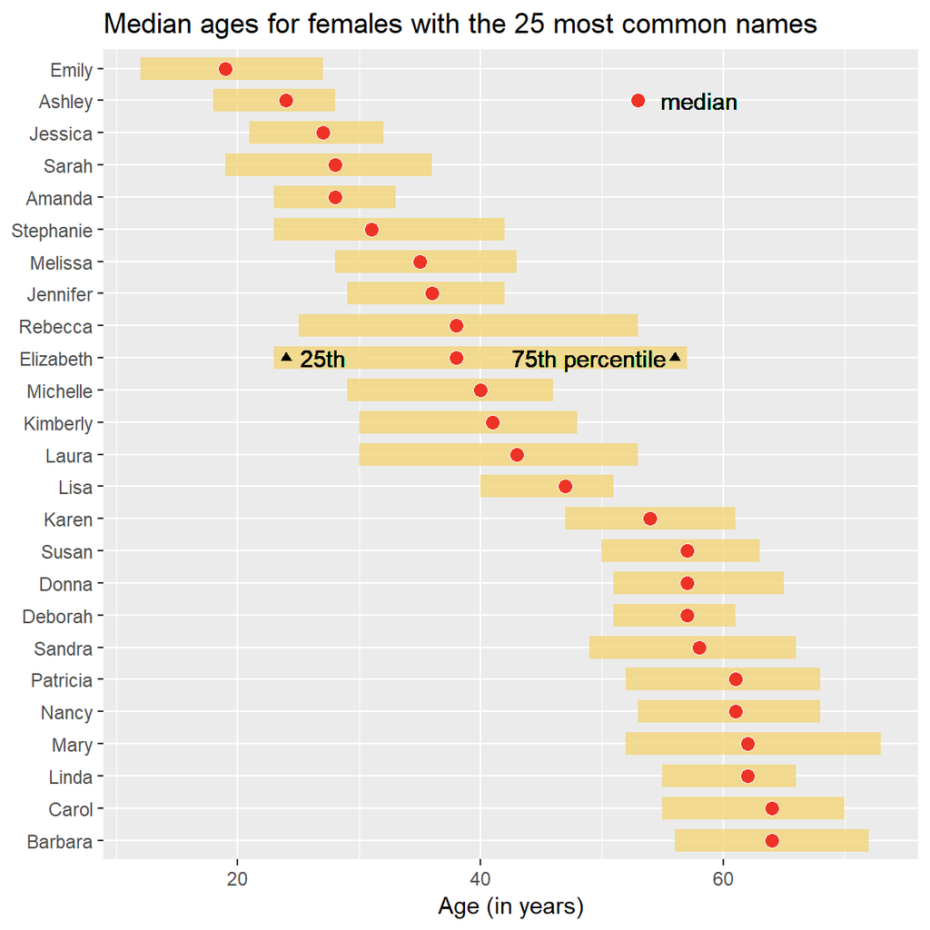

```r
w_plot +
  geom_linerange(
    aes(ymin = q1_age, ymax = q3_age),
    color = "#f3d478",
    size = 5,
    alpha = 0.8
    ) +
  geom_point(fill = "#ed3324", colour = "white", size = 3, shape = 21) +
  geom_point(aes(y=53,x=24),fill = "#ed3324", colour = "white", size = 3, shape = 21) +
  geom_text(aes(y=58,x=24),label="median",cex=3.8)+
  geom_text(aes(y=27,x=16),label="25th",cex=3.8)+
  geom_text(aes(y=49,x=16),label="75th percentile",cex=3.8)+
  geom_point(aes(y=24,x=16),shape=17)+
  geom_point(aes(y=56,x=16),shape=17)+
  coord_flip()
```

Notice that your graphic is different from Nate Silver’s (the figure above). You are using more up-to-date data!

## 2. Summarizing groups

In this section, we will use the original `babynames` dataset, and learn how to use the `group_by()` function in conjunction with the `summarize()` verb that we learned previously.

```r
library(dplyr)
library(babynames)
head(babynames, 2)
```

```
## # A tibble: 2 x 5
##    year sex   name      n   prop
##   <dbl> <chr> <chr> <int>  <dbl>
## 1  1880 F     Mary   7065 0.0724
## 2  1880 F     Anna   2604 0.0267
```

We will answer the following question:

In which year was “Jackie” given to M and F babies most equally (i.e. **closest to a 50/50 split**)?

How would you do this? You could, of course, scan the data visually to estimate the percentages in each year:

```r
babynames %>%
  filter(name == "Jackie")
```

```
## # A tibble: 225 x 5
##     year sex   name       n      prop
##    <dbl> <chr> <chr>  <int>     <dbl>
##  1  1899 F     Jackie     9 0.0000364
##  2  1900 F     Jackie    12 0.0000378
##  3  1901 F     Jackie     7 0.0000275
##  4  1902 F     Jackie     6 0.0000214
##  5  1903 F     Jackie    12 0.0000431
##  6  1904 F     Jackie    20 0.0000684
##  7  1904 M     Jackie     5 0.0000361
##  8  1905 F     Jackie     9 0.0000290
##  9  1906 F     Jackie    14 0.0000447
## 10  1907 F     Jackie    15 0.0000445
## # ... with 215 more rows
```

But this is very inefficient and does not provide an exact solution.

The key to solving this problem is to recognize that we need to collapse the **two** rows corresponding to each assigned sex in each year into a single row that contains the information for both sexes (this is the `group_by()` part). Unfortunately, there is no way for R to know what to compute its own – we have to tell it (this is the `summarise()` part).

The `group_by` function specifies a variable on which the data frame will be collapsed. Each row in the result set will correspond to one unique value of that variable. In this case, we want to group by `year`. [This is sometimes called “rolling up” a data set.]

```r
babynames %>%
  filter(name == "Jackie") %>%
  group_by(year)
```

```
## # A tibble: 225 x 5
## # Groups:   year [117]
##     year sex   name       n      prop
##    <dbl> <chr> <chr>  <int>     <dbl>
##  1  1899 F     Jackie     9 0.0000364
##  2  1900 F     Jackie    12 0.0000378
##  3  1901 F     Jackie     7 0.0000275
##  4  1902 F     Jackie     6 0.0000214
##  5  1903 F     Jackie    12 0.0000431
##  6  1904 F     Jackie    20 0.0000684
##  7  1904 M     Jackie     5 0.0000361
##  8  1905 F     Jackie     9 0.0000290
##  9  1906 F     Jackie    14 0.0000447
## 10  1907 F     Jackie    15 0.0000445
## # ... with 215 more rows
```

This doesn’t actually do much, since we haven’t told R what to compute. `summarise()` takes a list of definitions for columns you want to see in the result set. The key to understanding `summarise()` is to note that it operates on vectors (which may contain many values), but it **must return a single value**. [Why?] Thus, the variables defined by the arguments to `summarise()` are usually *aggregate* functions like `sum()`, `mean()`, `length()`, `max()`, `n()`, etc.

```r
babynames1 <- babynames %>%
  filter(name == "Jackie") %>%
  group_by(year) %>%
  summarise(
    N = n(),
    total = sum(n),
    boys = sum(ifelse(sex == "M",n, 0))
  )
babynames1
```

```
## # A tibble: 117 x 4
##     year     N total  boys
##    <dbl> <int> <int> <dbl>
##  1  1899     1     9     0
##  2  1900     1    12     0
##  3  1901     1     7     0
##  4  1902     1     6     0
##  5  1903     1    12     0
##  6  1904     2    25     5
##  7  1905     1     9     0
##  8  1906     1    14     0
##  9  1907     1    15     0
## 10  1908     2    28     5
## # ... with 107 more rows
```